# Northern Gulf of Mexico Sharks (Draft)

Alex Benecke

July 20, 2018

## Introduction

…We used Generalized Additive Models (GAMs) to describe the spatial distribution and abundance of 8 species of northern Gulf of Mexico (GoM) sharks.

## Methods

To ensure only good quality data was used in the model building process basic descriptive statistics and plots were generated for CPUE and the explanatory variables. Erroneous salinity values were removed if values were greater than 40 or less than 15 PSU. Values for bottom dissolved oxygen were removed if they were equal to 0 or greater than 12 $mg*L^{-1}$. Bottom fluorometry and turbidity were not used as explanatory variables due to a high proportion of missing data (n = 1869, 925 respectively). Correlation between variables was assessed using a correlation matrix and pairwise scatter plots.

We utilized a two strata generalized additive model (GAM) to investigate the relationship between the spatial distribution of northern GoM shark species and a suite of environmental variables. The first stratum modeled the presents-absence of northern GoM sharks assuming a binomial error distribution and a log link function. The second strata modeled the CPUE of northern GoM sharks including only stations with positive catch and assuming a gamma error distribution and a log link function. The full model is given as:
$$g_{1}(y) = g_{2}(Lon, Lat) + \sum^{n}_{i=1} s_{i}(x_{i}) + factor(Bottom ~ Substrate) + re_{yr} + \epsilon$$
where $g_1()$ is the link function for the response variable $y$, $g_{2}(Lon, Lat)$ is 2-dimensional isotropic thin plate regression spline (TPRS) smooth of Latitude and Longitude, $s_{i}(x_i)$ is the $i^{th}$ 1-dimensional TPRS smooth of the $i^th$ predictor variable $x$, $factor(Bottom Substrate)$ is a factor variable for bottom substrate, $re_{yr}$ is a random effect for year, and $\epsilon$ is random error. Basis dimensions ($k$) were estimated using the formula suggested by Kim and Gu (2004) k=10*n^(2/9) where n is the number of data.

## References

Kim, Y.I., Gu, C. (2004) Smoothing spline Gaussian regression: more scalable computation via efficient approximation. Journal of the Royal Statistical Society, Series B 66, 337-356.

R Core Team (2018). R: A language and environment for statistical computing. R Foundation for Statistical Computing, Vienna, Austria. URL https://www.R-project.org/ (R version 3.5.0)

Wood, S.N. (2011) Fast stable restricted maximum likelihood and marginal likelihood estimation of semiparametric generalized linear models. Journal of the Royal Statistical Society (B) 73(1):3-36

Wood, S.N. (2004) Stable and efficient multiple smoothing parameter estimation for generalized additive models. Journal of the American Statistical Association. 99:673-686.

## Tables

### Table 1

**Note:** *Simplify Table 1 to be only the best models for each species. Or maybe top few models for each species*

#### (a) Blacknose

```r
bn_gam_select_1$results
```

| model | NoOfCoef | AIC | BIC | GCV |
| --- | --- | --- | --- | --- |
| Lon, Lat, Lat-Lon, Dep, Oxy, Sal, Yr | 7 | 6797.959 | 7769.894 | 0.3196816 |
| Lat, Lat-Lon, Dep, Oxy, Sal, Yr | 6 | 6797.959 | 7769.893 | 0.3196816 |
| Lon, Lat-Lon, Dep, Oxy, Sal, Yr | 6 | 6839.971 | 7771.304 | 0.3232233 |
| Lat-Lon, Dep, Oxy, Sal, Yr | 5 | 6839.971 | 7771.304 | 0.3232233 |
| Lon, Lat, Lat-Lon, Dep, Sal, Yr | 6 | 6843.308 | 7800.578 | 0.3220880 |
| Lat, Lat-Lon, Dep, Sal, Yr | 5 | 6843.308 | 7800.578 | 0.3220880 |
| Lon, Lat, Lat-Lon, Dep, Oxy, Yr | 6 | 6862.384 | 7632.714 | 0.3221866 |
| Lat, Lat-Lon, Dep, Oxy, Yr | 5 | 6862.386 | 7632.703 | 0.3221866 |
| Lat, Lat-Lon, Oxy, Yr | 4 | 6873.797 | 7666.421 | 0.3236237 |
| Lon, Lat, Lat-Lon, Oxy, Yr | 5 | 6873.798 | 7666.416 | 0.3236237 |

[output cut: 117 more lines]

Number of models 127

user system elapsed

4.43 3.02 1239.10 $\approx$ 20 min

#### (b) Blacktip

```r
bt_gam_select$results
```

| model | NoOfCoef | AIC | BIC | GCV |
| --- | --- | --- | --- | --- |
| Lat, Lat-Lon, Dep, Oxy, Sal, Yr | 6 | 5783.867 | 6734.395 | 0.2512818 |
| Lon, Lat, Lat-Lon, Dep, Oxy, Sal, Yr | 7 | 5783.872 | 6734.373 | 0.2512818 |
| Lon, Lat-Lon, Dep, Oxy, Sal, Yr | 6 | 5784.755 | 6732.024 | 0.2513041 |
| Lat-Lon, Dep, Oxy, Sal, Yr | 5 | 5784.755 | 6732.024 | 0.2513041 |
| Lat, Lat-Lon, Oxy, Sal, Yr | 5 | 5822.758 | 6778.096 | 0.2544348 |
| Lon, Lat, Lat-Lon, Oxy, Sal, Yr | 6 | 5823.143 | 6776.854 | 0.2544411 |
| Lon, Lat-Lon, Oxy, Sal, Yr | 5 | 5823.145 | 6776.850 | 0.2544412 |
| Lat-Lon, Oxy, Sal, Yr | 4 | 5823.147 | 6776.843 | 0.2544412 |
| Lon, Lat, Lat-Lon, Dep, Sal, Yr | 6 | 5838.285 | 6772.184 | 0.2537508 |
| Lat, Lat-Lon, Dep, Sal, Yr | 5 | 5838.334 | 6771.966 | 0.2537507 |

[output cut: 117 more lines]

Number of models 127

user system elapsed

3.72 2.60 1291.12 $\approx$ 21 min

#### (c) Bull

```r
bu_gam_select$results
```

| model | NoOfCoef | AIC | BIC | GCV |
| --- | --- | --- | --- | --- |
| Lat, Lat-Lon, Oxy, Sal | 4 | 53.08205 | 1078.9386 | 0.05577072 |
| Lon, Lat, Lat-Lon, Oxy, Sal, Yr | 6 | 77.07226 | 944.1361 | 0.05570024 |
| Lat, Lat-Lon, Oxy, Sal, Yr | 5 | 77.07608 | 944.1152 | 0.05570023 |
| Lon, Lat-Lon, Dep, Oxy, Sal, Yr | 6 | 80.01999 | 1051.9034 | 0.05609576 |
| Lat-Lon, Dep, Oxy, Sal, Yr | 5 | 80.02003 | 1051.9030 | 0.05609576 |
| Lat, Lat-Lon, Dep, Oxy, Sal, Yr | 6 | 87.56724 | 938.7541 | 0.05584494 |
| Lon, Lat, Lat-Lon, Dep, Oxy, Sal, Yr | 7 | 87.56786 | 938.7587 | 0.05584496 |
| Lon, Lat, Lat-Lon, Oxy, Sal | 5 | 91.82364 | 921.4689 | 0.05585636 |
| Lon, Lat, Lat-Lon, Dep, Sal, Yr | 6 | 96.78555 | 856.4749 | 0.05573273 |
| Lat, Lat-Lon, Dep, Sal, Yr | 5 | 96.78582 | 856.4766 | 0.05573274 |

[output cut: 117 more lines]

Number of models 127

user system elapsed

1.94 2.45 1161.04 $\approx$ 19 min

#### (d) Sandbar

```r
sb_gam_select$results
```

| model | NoOfCoef | AIC | BIC | GCV |
| --- | --- | --- | --- | --- |
| Lon, Lat, Lat-Lon, Dep, Oxy, Sal, Yr | 7 | 2889.232 | 3487.723 | 0.1234186 |
| Lat, Lat-Lon, Dep, Oxy, Sal, Yr | 6 | 2889.232 | 3487.723 | 0.1234186 |
| Lon, Lat-Lon, Dep, Oxy, Sal, Yr | 6 | 2892.681 | 3489.384 | 0.1235476 |
| Lat-Lon, Dep, Oxy, Sal, Yr | 5 | 2892.683 | 3489.372 | 0.1235476 |
| Lon, Lat, Lat-Lon, Dep, Oxy, Yr | 6 | 2892.813 | 3471.181 | 0.1233975 |
| Lat, Lat-Lon, Dep, Oxy, Yr | 5 | 2892.813 | 3471.180 | 0.1233975 |
| Lon, Lat, Lat-Lon, Dep, Sal, Yr | 6 | 2896.432 | 3450.720 | 0.1231635 |
| Lat, Lat-Lon, Dep, Sal, Yr | 5 | 2896.433 | 3450.711 | 0.1231635 |
| Lon, Lat-Lon, Dep, Oxy, Yr | 5 | 2896.668 | 3474.222 | 0.1235497 |
| Lat-Lon, Dep, Oxy, Yr | 4 | 2896.669 | 3474.214 | 0.1235497 |

[output cut: 117 more lines]

Number of models 127

user system elapsed

1.77 2.87 746.13 $\approx$ 12 min

#### (e) Sharpnose

```r
sn_gam_select_2$results
```

| model | NoOfCoef | AIC | BIC | GCV |
| --- | --- | --- | --- | --- |
| Lon, Lat, Lat-Lon, Dep, temp, Oxy, Sal, Yr | 8 | 12763.78 | 13704.87 | 0.6979028 |
| Lat, Lat-Lon, Dep, temp, Oxy, Sal, Yr | 7 | 12771.40 | 13682.59 | 0.6981341 |
| Lon, Lat-Lon, Dep, temp, Oxy, Sal, Yr | 7 | 12782.77 | 13664.87 | 0.6992166 |
| Lat-Lon, Dep, temp, Oxy, Sal, Yr | 6 | 12782.77 | 13664.87 | 0.6992171 |
| Lon, Lat, Lat-Lon, Dep, temp, Oxy, Yr | 7 | 12813.49 | 13729.72 | 0.7068986 |
| Lon, Lat, Lat-Lon, temp, Oxy, Sal, Yr | 7 | 12821.52 | 14107.03 | 0.7271715 |
| Lat, Lat-Lon, Dep, temp, Oxy, Yr | 6 | 12822.84 | 13702.60 | 0.7072010 |
| Lon, Lat, Lat-Lon, Dep, temp, Sal, Yr | 7 | 12831.80 | 13715.59 | 0.7026393 |
| Lat, Lat-Lon, Dep, temp, Sal, Yr | 6 | 12831.80 | 13715.59 | 0.7026394 |
| Lon, Lat-Lon, Dep, temp, Oxy, Yr | 6 | 12836.74 | 13678.89 | 0.7084488 |

[output cut: 245 more lines]

Number of models 255

user system elapsed

3.92 5.59 4214.18 $\approx$ 1 hr 10 min

#### (f) Silky

```r
si_gam_select$results
```

| model | NoOfCoef | AIC | BIC | GCV |
| --- | --- | --- | --- | --- |
| Lon, Lat, Dep, Sal, Yr | 5 | -1536.578 | -1143.4725 | 0.03314482 |
| Lon, Lat, Lat-Lon, Dep, Sal, Yr | 6 | -1535.131 | -1123.1109 | 0.03319260 |
| Lon, Lat, Dep, Oxy, Yr | 5 | -1527.484 | -1134.0843 | 0.03320299 |
| Lon, Lat, Dep, Oxy, Sal, Yr | 6 | -1524.696 | -1125.9300 | 0.03323690 |
| Lon, Lat-Lon, Dep, Oxy, Sal, Yr | 6 | -1523.522 | -1105.4415 | 0.03328264 |
| Lon, Lat-Lon, Dep, Sal, Yr | 5 | -1517.418 | -1164.5095 | 0.03329097 |
| Lat-Lon, Dep, Sal, Yr | 4 | -1517.417 | -1164.5098 | 0.03329097 |
| Lat, Lat-Lon, Dep, Sal, Yr | 5 | -1517.417 | -1164.5059 | 0.03329098 |
| Lon, Lat, Dep, Sal | 4 | -1514.598 | -1169.3096 | 0.03330977 |
| Lon, Lat-Lon, Dep, Oxy, Yr | 5 | -1513.996 | -1110.9079 | 0.03337001 |

[output cut: 117 more lines]

Number of models 127

#### (g) Spinner

```r
sp_gam_select$results
```

| model | NoOfCoef | AIC | BIC | GCV |
| --- | --- | --- | --- | --- |
| Lon, Lat, Lat-Lon, Dep, Oxy, Sal, Yr | 7 | 3704.023 | 4685.214 | 0.1692529 |
| Lat, Lat-Lon, Dep, Oxy, Sal, Yr | 6 | 3714.595 | 4652.140 | 0.1693956 |
| Lon, Lat, Lat-Lon, Oxy, Sal, Yr | 6 | 3719.896 | 4619.641 | 0.1692462 |
| Lon, Lat-Lon, Oxy, Sal, Yr | 5 | 3725.394 | 4612.577 | 0.1694262 |
| Lat, Lat-Lon, Oxy, Sal, Yr | 5 | 3727.551 | 4595.385 | 0.1693520 |
| Lon, Lat-Lon, Dep, Oxy, Sal, Yr | 6 | 3727.819 | 4621.247 | 0.1696864 |
| Lat-Lon, Oxy, Sal, Yr | 4 | 3733.101 | 4589.026 | 0.1695424 |
| Lat-Lon, Dep, Oxy, Sal, Yr | 5 | 3737.964 | 4591.823 | 0.1698553 |
| Lon, Lat, Lat-Lon, Dep, Oxy, Yr | 6 | 3739.184 | 4719.587 | 0.1711542 |
| Lon, Lat-Lon, Dep, Oxy, Yr | 5 | 3745.740 | 4715.795 | 0.1714164 |

[output cut: 117 more lines]

Number of models 127

#### (h) Tiger

```r
ti_gam_select$results
```

| model | NoOfCoef | AIC | BIC | GCV |
| --- | --- | --- | --- | --- |
| Lon, Lat, Lat-Lon, Dep, Oxy, Sal, Yr | 7 | 832.4169 | 1476.996 | 0.06869162 |
| Lat, Lat-Lon, Dep, Oxy, Sal, Yr | 6 | 832.4350 | 1476.898 | 0.06869160 |
| Lat, Lat-Lon, Dep, Oxy, Yr | 5 | 848.7440 | 1498.855 | 0.06908386 |
| Lon, Lat, Lat-Lon, Dep, Oxy, Yr | 6 | 848.7519 | 1498.825 | 0.06908390 |
| Lon, Lat-Lon, Dep, Oxy, Sal, Yr | 6 | 856.4772 | 1379.438 | 0.06879485 |
| Lat-Lon, Dep, Oxy, Sal, Yr | 5 | 856.4805 | 1379.417 | 0.06879483 |
| Lon, Lat, Lat-Lon, Oxy, Sal, Yr | 6 | 859.8219 | 1394.626 | 0.06891081 |
| Lat, Lat-Lon, Oxy, Sal, Yr | 5 | 859.8219 | 1394.626 | 0.06891081 |
| Lon, Lat-Lon, Oxy, Sal, Yr | 5 | 859.8229 | 1394.605 | 0.06891076 |
| Lat-Lon, Oxy, Sal, Yr | 4 | 859.8233 | 1394.601 | 0.06891075 |

[output cut: 117 more lines]

Number of models 127

## Figures

**Note:** *These are just placeholders I will do a nicer ggplot later*

### Figure 1

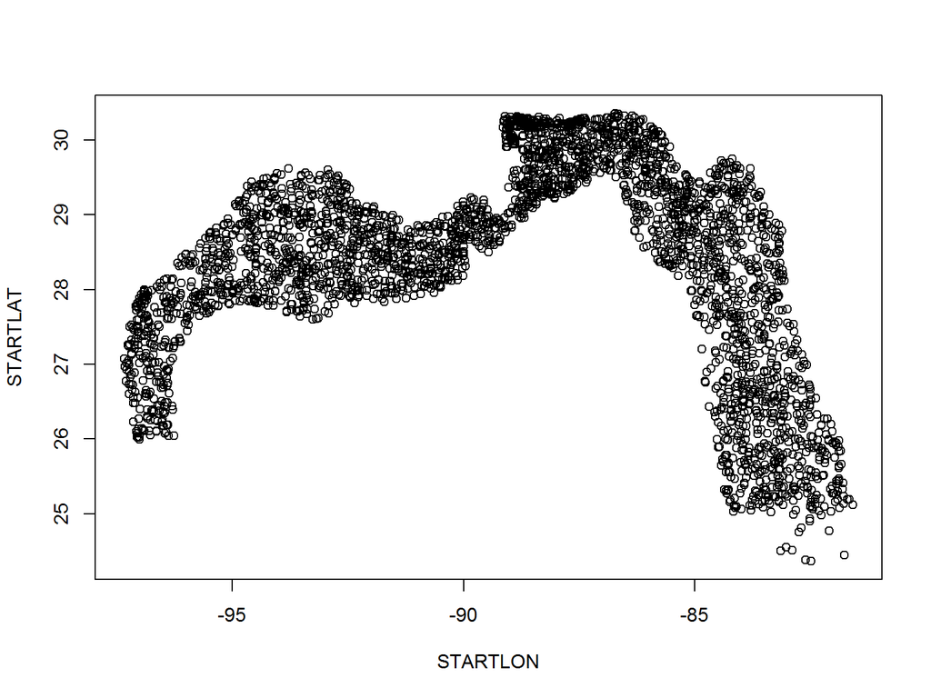

### Figure 2

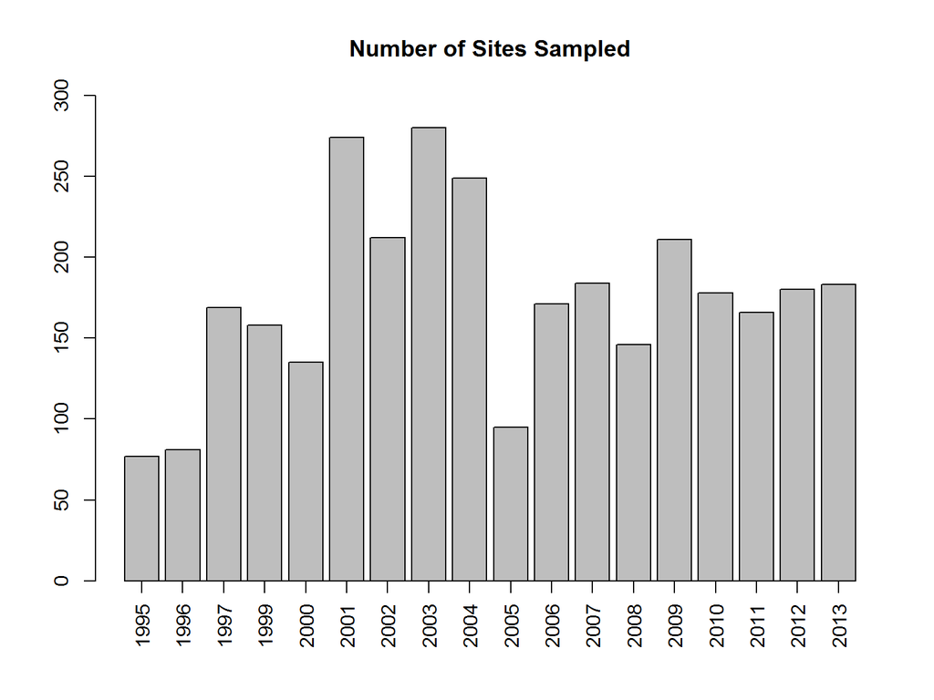